# R Notebook

##Discrete (countable & finite) and continuous variables (uncountable)

number of people in my survey who like blue = discrete value (whole num) height of people in Scotland = continuous (infinite decimal places)

age = continuous & numeric age group = ordinal & categoric no. of people in a household = continuous height = continuous numeric weight = continuous numeric shoe size = ordinal categoric

## Probability Mass & Probability Density

probability mass function <- probability distribution of a discrete variable

probability density function <- probability distribution of a continuous variable

we cannot measure probabilities of probability density functions, but can for mass functions - for continuous variable would have to be for a range of values

Discrete probability distributions: - outcome on X axis - y is probability of that outcome - sum of all probabilities = 1 - each probability between 0 and 1

Continuous probability distributions: - outcome on X axis - y is probability density - sum of all probabilities = 1 (area under line must be 1)

##Discrete Distributions

```r
library(tidyverse)
```

#uniform distribution - all probabilities are the same

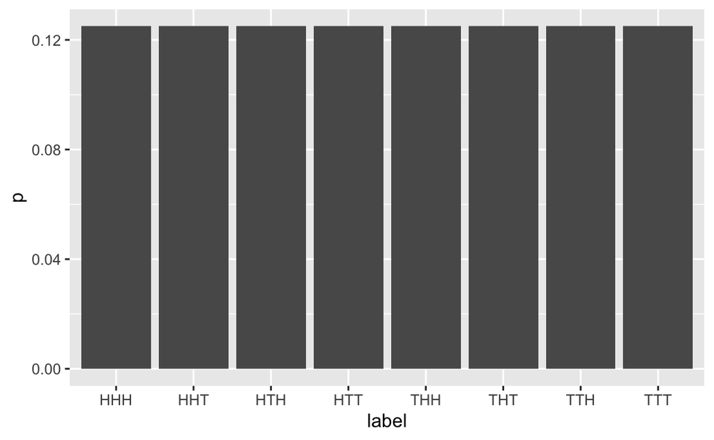

```r
tosscoin(3) %>%
  mutate(label = str_c(toss1, toss2, toss3, sep = "")) %>%
  mutate(p = 1/n()) %>%
  ggplot(aes(label, p))+
  geom_col()
```

#cumulative distribution fucntion (i.e. roll 1 or less, 2 or less…)

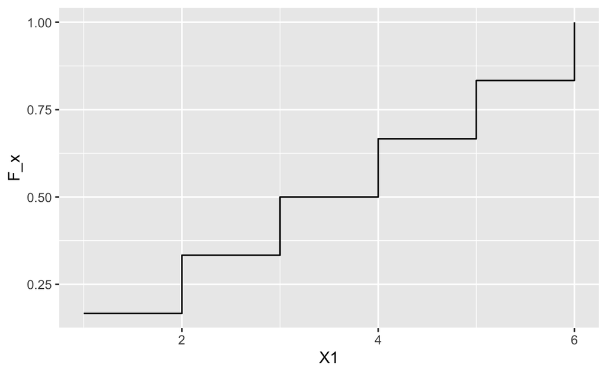

```r
rolldie(1) %>%
  mutate(p = 1/n()) %>%
  mutate(F_x = cumsum(p)) %>%
  ggplot(aes(X1, F_x))+
  geom_step()
```

##Continuous Distributions

#Continuous uniform >length of breaks were found to be uniformly distributed between 5 mins and 22 mins >probability density function of length (l)

distribution finctions: d - distribution r - random numbers q - quantile p - cumulative density function

| length | f_length | F_length |
| --- | --- | --- |
| 4.0 | 0.00000000 | 0.000000000 |
| 4.1 | 0.00000000 | 0.000000000 |
| 4.2 | 0.00000000 | 0.000000000 |
| 4.3 | 0.00000000 | 0.000000000 |
| 4.4 | 0.00000000 | 0.000000000 |
| 4.5 | 0.00000000 | 0.000000000 |
| 4.6 | 0.00000000 | 0.000000000 |
| 4.7 | 0.00000000 | 0.000000000 |
| 4.8 | 0.00000000 | 0.000000000 |
| 4.9 | 0.00000000 | 0.000000000 |

[output cut: 181 more lines]

whats the probability of a brain break lasting between 8.4 and 10.7?

```r
f_8_4
```

[output not shown]

#showing this range on the initial plot

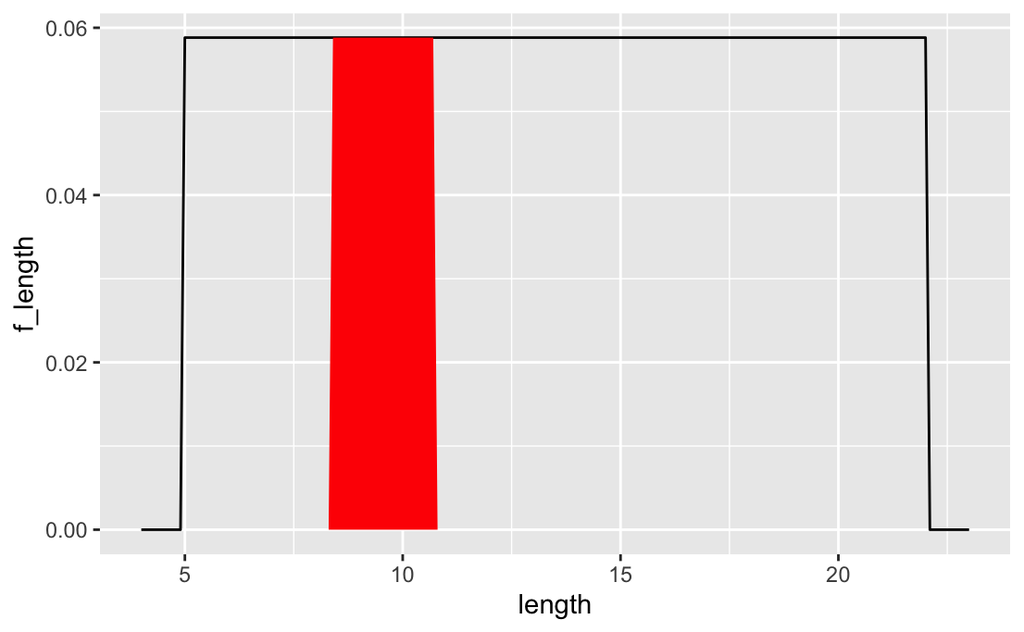

```r
brain_break %>%
  ggplot(aes(x = length, y = f_length))+
  geom_line()+
  geom_ribbon(aes(ymin = 0, ymax = ifelse(
    length >= 8.4 & length <= 10.7, f_length, 0
  )), fill = "red")
```

##Normal Distribution

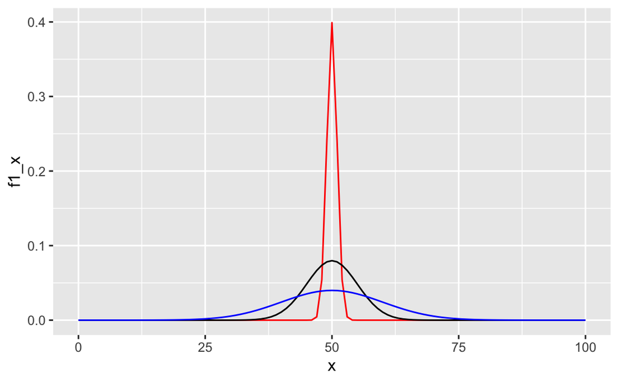

#How to tell if your data is normally distributed - compare it to a normal dataset #1 plot histogram #2 change metric of histogram ..density.. #3 stat function to overlay normal distribution

```r
accounting_position_stats <- jobs %>%
  filter(position == "Accounting") %>%
  summarise(
    num = n(),
    mean = mean(salary),
    st_dev = sd(salary)
  )
```

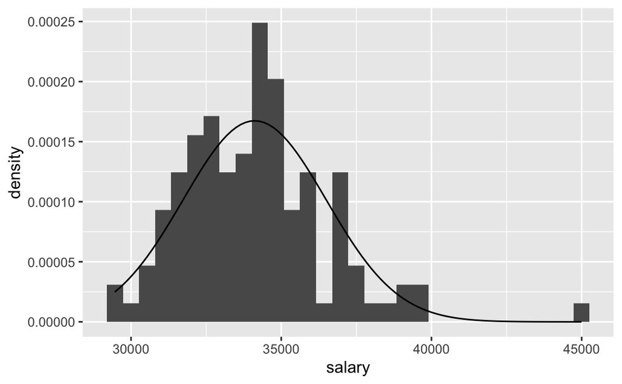

```r
jobs %>%
  filter(position == "Accounting") %>%
  ggplot(aes(x = salary))+
  geom_histogram(aes(y = ..density..))+ # turns from count to prob density scale
  stat_function(
    fun = ~dnorm(., mean = accounting_position_stats$mean,
                 sd = accounting_position_stats$st_dev)
  )
```

“Standard Normal” - scaled so that the mean = 0 & sd = 1

z: tells us how far away we are from the mean in units of standard deviation - if z>3 then point is considered an outlier - x - mean / sd

| position | salary | z_salary | mean_sal |
| --- | --- | --- | --- |
| Management | 91027 | 3.66991 | 50876.15 |

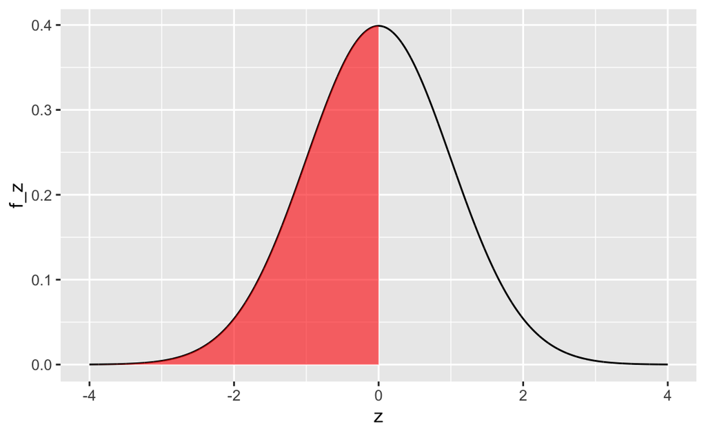

```r
shade_standard_normal <- function(shade_from, shade_to){
  standard_normal <- tibble(
    z = seq(from = -4, to = 4, by = 0.001),
    f_z = dnorm(x = z)
  )
  standard_normal %>%
    ggplot(aes(x = z, y = f_z)) +
    geom_line() +
    geom_ribbon(aes(ymin = 0, ymax = ifelse(z >= shade_from & z <= shade_to, f_z, 0)), fill = "red", alpha = 0.6)
}

shade_standard_normal(shade_from = -Inf, shade_to = 0)
```

# The empirical 3-sigma rule

most values lie within 3 standard deviations of the mean

#how many values should lie within 1 sd of mean for a normal distribution? - 68% should if its a normal distribution

```r
100*(pnorm(q=1) - pnorm(q = -1))
```

```
[1] 68.26895
```

```r
100*(pnorm(q=2) - pnorm(q = -2))
```

```
[1] 95.44997
```

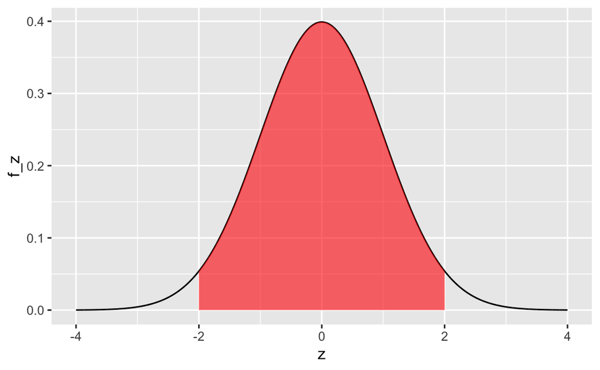

```r
shade_standard_normal(-2, 2)
```

-95% should be within 2 sd of the mean

```r
100*(pnorm(q=3) - pnorm(q = -3))
```

```
[1] 99.73002
```

-99.7% should be within 3 sd of the mean